# Segmenting Fruit Colors Using KNN

In this project we will be using a KNN model to predict fruits based on a variety of different numeric metrics.

```python
#import libraries

import pandas as pd
import numpy as np
import matplotlib.pyplot as plt
import seaborn as sns
```

```python
dat = pd.read_csv('fruit_data_with_colors.txt', sep="\t")
```

```python
dat.head()
```

|  | fruit_label | fruit_name | fruit_subtype | mass | width | height | color_score |
| --- | --- | --- | --- | --- | --- | --- | --- |
| 0 | 1 | apple | granny_smith | 192 | 8.4 | 7.3 | 0.55 |
| 1 | 1 | apple | granny_smith | 180 | 8.0 | 6.8 | 0.59 |
| 2 | 1 | apple | granny_smith | 176 | 7.4 | 7.2 | 0.60 |
| 3 | 2 | mandarin | mandarin | 86 | 6.2 | 4.7 | 0.80 |
| 4 | 2 | mandarin | mandarin | 84 | 6.0 | 4.6 | 0.79 |

Looking at the data we have 7 different fields. Our goal is to predict the fruit_name dimension. However, before we begin making our model we will take a closer look at the data so we can gain a better understanding of it.

Let's start by checking for NA values as well as looking at summary statistics for our dataset.

```python
dat.isna().sum()
```

```
fruit_label      0
fruit_name       0
fruit_subtype    0
mass             0
width            0
height           0
color_score      0
dtype: int64
```

```python
dat.describe(include='all')
```

|  | fruit_label | fruit_name | fruit_subtype | mass | width | height | color_score |
| --- | --- | --- | --- | --- | --- | --- | --- |
| count | 59.000000 | 59 | 59 | 59.000000 | 59.000000 | 59.000000 | 59.000000 |
| unique | NaN | 4 | 10 | NaN | NaN | NaN | NaN |
| top | NaN | apple | turkey_navel | NaN | NaN | NaN | NaN |
| freq | NaN | 19 | 10 | NaN | NaN | NaN | NaN |
| mean | 2.542373 | NaN | NaN | 163.118644 | 7.105085 | 7.693220 | 0.762881 |
| std | 1.208048 | NaN | NaN | 55.018832 | 0.816938 | 1.361017 | 0.076857 |
| min | 1.000000 | NaN | NaN | 76.000000 | 5.800000 | 4.000000 | 0.550000 |
| 25% | 1.000000 | NaN | NaN | 140.000000 | 6.600000 | 7.200000 | 0.720000 |
| 50% | 3.000000 | NaN | NaN | 158.000000 | 7.200000 | 7.600000 | 0.750000 |
| 75% | 4.000000 | NaN | NaN | 177.000000 | 7.500000 | 8.200000 | 0.810000 |
| max | 4.000000 | NaN | NaN | 362.000000 | 9.600000 | 10.500000 | 0.930000 |

Our data looks clean! Overall we have 59 observations of 4 unique fruits.

```python
dat.groupby(['fruit_name']).mean()
```

| fruit_name | fruit_label | mass | width | height | color_score |
| --- | --- | --- | --- | --- | --- |
| apple | 1.0 | 165.052632 | 7.457895 | 7.342105 | 0.783684 |
| lemon | 4.0 | 150.000000 | 6.512500 | 8.856250 | 0.718125 |
| mandarin | 2.0 | 81.200000 | 5.940000 | 4.380000 | 0.796000 |
| orange | 3.0 | 193.789474 | 7.557895 | 7.936842 | 0.771053 |

```python
dat.groupby(['fruit_name','fruit_subtype']).mean()
```

| fruit_name | fruit_subtype | fruit_label | mass | width | height | color_score |
| --- | --- | --- | --- | --- | --- | --- |
| apple | braeburn | 1.0 | 168.400000 | 7.100000 | 7.360000 | 0.908000 |
|  | cripps_pink | 1.0 | 158.333333 | 7.450000 | 7.366667 | 0.855000 |
|  | golden_delicious | 1.0 | 159.200000 | 7.540000 | 7.440000 | 0.696000 |
|  | granny_smith | 1.0 | 182.666667 | 7.933333 | 7.100000 | 0.580000 |
| lemon | spanish_belsan | 4.0 | 194.333333 | 7.266667 | 10.000000 | 0.715000 |
|  | unknown | 4.0 | 123.400000 | 6.060000 | 8.170000 | 0.720000 |
| mandarin | mandarin | 2.0 | 81.200000 | 5.940000 | 4.380000 | 0.796000 |
| orange | selected_seconds | 3.0 | 172.666667 | 7.216667 | 7.700000 | 0.785000 |
|  | spanish_jumbo | 3.0 | 353.333333 | 9.266667 | 9.266667 | 0.746667 |
|  | turkey_navel | 3.0 | 158.600000 | 7.250000 | 7.680000 | 0.770000 |

If we examine the mean values for the different metrics we see large differences between the different fruits. For example, mandarin's have low height and low width while lemon's have high height and moderate width. Breaking the fruits down further we can see that there are also differences between different subtypes of the same fruit. For example, the color score is extremely different for the various apple subtypes. Since our original goal was to predict the fruit names, we will be ignoring these subtypes moving forward.

Now that we have seen the average values by fruit_name, let's take a look at the distribution of these values.

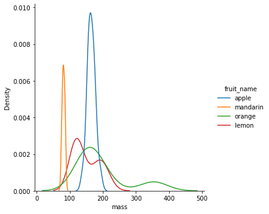

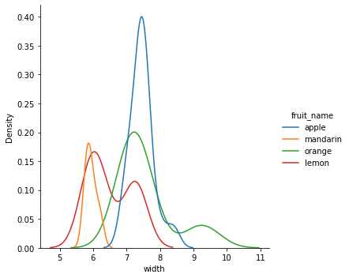

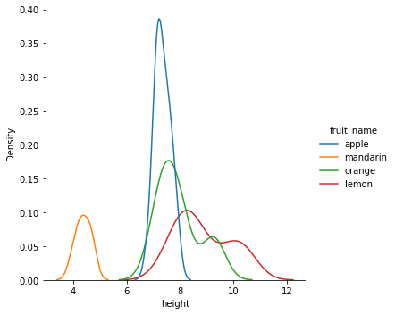

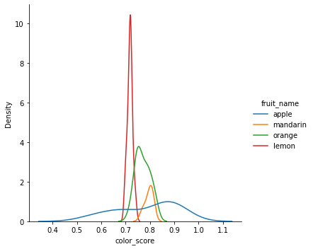

```python
cols = dat.columns

for i in range(3,len(cols)):
    plot = sns.displot(x=cols[i], data=dat, hue='fruit_name', kind='kde')
```

These distributions point to some interesting observations. For example, apples mass, width, and height are all closely distributed while their color_score distribution is very spread out.

Now we will begin building the model. First, let's import the necessary libraries.

```python
from sklearn.metrics import confusion_matrix
from sklearn.neighbors import KNeighborsClassifier
from sklearn.model_selection import train_test_split
from sklearn.preprocessing import StandardScaler
```

Next we will divide our data into our x and y. We will also need to scale our data. This is a crucial part of the process since KNN is based off euclidean distance.

```python
X = dat[['mass','color_score','width','height']]
y = dat.fruit_name

scaler = StandardScaler()
scaler.fit(X)
X = scaler.transform(X)
```

Now we will split our data into a training and testing set and fit our model.

```python
X_train, X_test, y_train, y_test = train_test_split(X, y)
```

```python
knn = KNeighborsClassifier(n_neighbors=5, metric='euclidean')
knn.fit(X_train, y_train)
```

```
KNeighborsClassifier(metric='euclidean')
```

Let's see predicted based off our test data as well as the overall accuracy score of our initial attempt.

```python
y_pred = knn.predict(X_test)
y_pred
```

```
array(['lemon', 'orange', 'orange', 'lemon', 'apple', 'apple', 'lemon',
       'mandarin', 'orange', 'apple', 'orange', 'orange', 'apple',
       'lemon', 'apple'], dtype=object)
```

```python
knn.score(X_test,y_test)
```

```
0.8666666666666667
```

Not bad! But let's see if we can do even better. We can tune our model by finding the optimal k. To do this, we will create multiple KNN models using a variety of different values for N. We can then compare accuracy scores to determine the best model.

```python
test = []
for i in range(0,9):
    knn = KNeighborsClassifier(n_neighbors=i+1, metric='euclidean')
    knn.fit(X_train, y_train)
    score = knn.score(X_test,y_test)
    test.append(score)
```

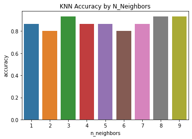

```python
score_df = pd.DataFrame({'n_neighbors': [1,2,3,4,5,6,7,8,9], 'accuracy': test})

accuracy_plot = sns.barplot(data=score_df, x='n_neighbors',y='accuracy').set(title='KNN Accuracy by N_Neighbors')
```

The default for the KNN algorithm is k=5. From the data above we can see that this is not the optimal value. Instead, we will choose k=3.

Let's see how our model's score improves using this new k.

```python
knn = KNeighborsClassifier(n_neighbors=3, metric='euclidean')
knn.fit(X_train, y_train)
score = knn.score(X_test,y_test)
score
```

```
0.9333333333333333
```

By optimizing the N in our KNN algorithm we dramatically improved our accuracy score. Finally, let's look at a confusion Matrix to get a better sense of our model's performance.

```python
values = ['apple','lemon','mandarin','orange']

cm = pd.DataFrame(confusion_matrix(y_test, knn.predict(X_test)), columns=values, index=values)
```

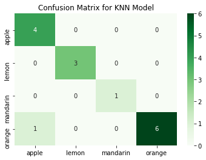

```python
confusion = sns.heatmap(cm, annot=True, fmt='d', cmap='Greens').set(title='Confusion Matrix for KNN Model')
```